# Assignment 5- Plot 3

```python
from matplotlib import pyplot as plt
import pandas as pd
import numpy as np
import warnings
warnings.filterwarnings(action='ignore')
```

```python
df=pd.read_csv('Motor_Vehicle_Collisions_-_Crashes.csv')
```

```python
df['CRASH YEAR'] = pd.to_datetime(df['CRASH DATE'], format='%m/%d/%Y').dt.year
df['CRASH HOUR']=pd.to_datetime(df['CRASH TIME'], format='%H:%M').dt.hour
```

```python
data=df.groupby(['BOROUGH','CRASH HOUR']).count()['COLLISION_ID']
```

```python
BOROUGH=["BRONX","BROOKLYN","MANHATTAN","QUEENS","STATEN ISLAND"]
```

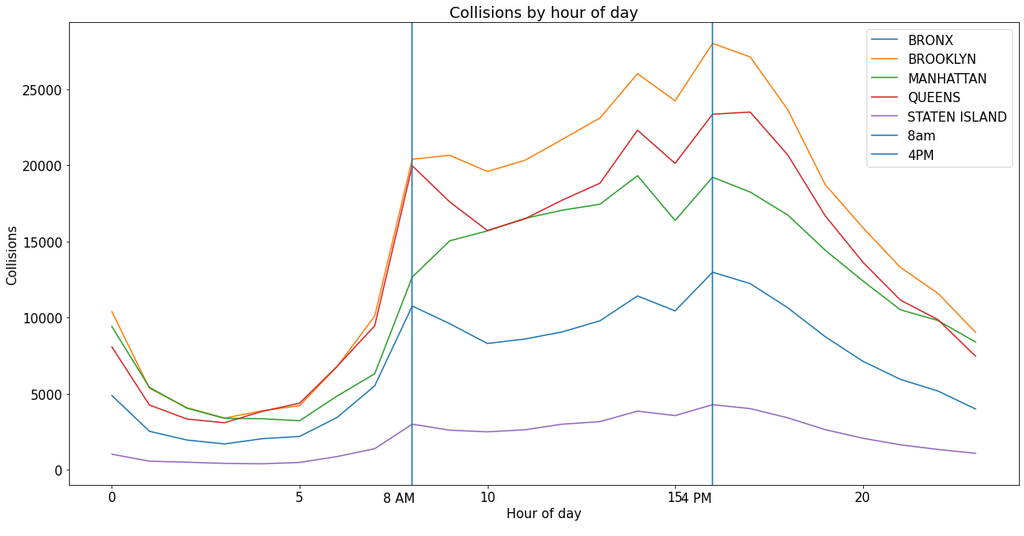

```python
plt.rcParams.update({'font.size': 15})

fig, ax = plt.subplots()
fig.set_size_inches(w=20,h=10)

for i in range(len(BOROUGH)):
    data[BOROUGH[i]].plot(label=f"{BOROUGH[i]}")

plt.axvline(x=8,label='8am');
plt.axvline(x=16, label='4PM');
ax.annotate('8 AM',
            xy=(450, 40), xycoords='figure pixels')

ax.annotate('4 PM',
            xy=(800, 40), xycoords='figure pixels')
plt.title("Collisions by hour of day");
plt.legend();
plt.xlabel("Hour of day");
plt.ylabel('Collisions');
```

# Report

### Dataset

For this assignment, I have used the NYC Motor Vehicle Collisions and Crashes dataset. The dataset has more than 1.7 million rows. I downloaded the dataset from the https://data.cityofnewyork.us/Public-Safety/Motor-Vehicle-Collisions-Crashes/h9gi-nx95. The dataset is open to public and free for non-commerical use.

The dataset contains comprehensive information of motor vehicles collisions across NYC from 2012-2020. This dataset has been cited in a lot of research papers and news articles. My visualizations are inspired by a blog publised on nycdatascience.com. (**Link-** https://data.cityofnewyork.us/Public-Safety/Motor-Vehicle-Collisions-Crashes/h9gi-nx95). Code to generate the visualizations is solely my own. I used the article only as an inspiration to create these visualizations.

**Note:** Since the dataset is large, I was getting memory overflow issues- I had to save multiple copies of the data frame. So, I decided the split the plots into three notebooks.

### Plot 1

The first plot illustrates the total collisions across various BOROUGHS in NYC over the years 2012-2020. I chose to use a grouped bar graph for this plot, since I am comparing the total collisions across BOROUGH each year.

**Inference:** From the plot, we can observe that over these 9 years, Brooklyn has been consistently most prone to Motor Vehicle Collisions.

### Plot 2

The second plot illustrates a breakdown of the type of victims involved in the collisions. Again, I chose to use a grouped bar graph for this plot, since I am comparing the total between different types of victims each year.

**Inference:** Motorists are more prone to motor vehicle collisions. Although this conclusion seems redundant, on further analysis, I found out that it's actually the pedestrians who most "severly" affected by motor vehicle collisions.